# Heart dataset descriptive analysis

Julián Alejandro Úsuga Ortiz

3/23/2022

## What is this data about?

This data set called **heart** is collected from the R library **catdata**

It gathers sample of males in a high-risk heart-disease region of Western Cape, South Africa. This study contains 10 variables which are the following:

- **age**: Age at onset of the study (Discrete Ordinal but i will treat them as Continuous) *
- **alcohol**: Alcohol consumption (Continuous) *
- **tobacco**: Cumulative tobacco consumption (Continuous) *
- **obesity**: Obesity (Continuous)
- **typea**: Type-A behavior (Continuous)
- **famhist**: Family history of heart disease (Binary, 1:Yes, 0:No) *
- **adiposity**: Adiposity / Fat gain (Continuous)
- **ldl**: Low density lipoprotein cholesterol (Continuous)
- **sbp**: Systolic blood pressure (Continuous) *
- **y**: Has coronary heart disease? (Binary, 1:Yes, 0:No) *

(* = will be analyzed)

## 1. Descriptive Statistics

As we can see in the following table, we have 4 continous variables and 2 discrete variables

- The ages range between 15 and 64 years
- Alcohol consumption ranges between 0 and 147
- Tobacco consumption ranges between 0 and 31.2
- sbp (Systolic blood pressure) ranges between 101 and 218
- ~41.55% of people have family history of this heart disease
- ~34.63% of people are diagnosed with this heart disease.

```
##       age           alcohol          tobacco             sbp        famhist
##  Min.   :15.00   Min.   :  0.00   Min.   : 0.0000   Min.   :101.0   0:270
##  1st Qu.:31.00   1st Qu.:  0.51   1st Qu.: 0.0525   1st Qu.:124.0   1:192
##  Median :45.00   Median :  7.51   Median : 2.0000   Median :134.0
##  Mean   :42.82   Mean   : 17.04   Mean   : 3.6356   Mean   :138.3
##  3rd Qu.:55.00   3rd Qu.: 23.89   3rd Qu.: 5.5000   3rd Qu.:148.0
##  Max.   :64.00   Max.   :147.19   Max.   :31.2000   Max.   :218.0
##  y
##  0:302
##  1:160
##
##
##
##
```

### Age

As we can see in the following plot the ages distribution is almost flat but it seems that the majority is in the group of ages ~40 and up

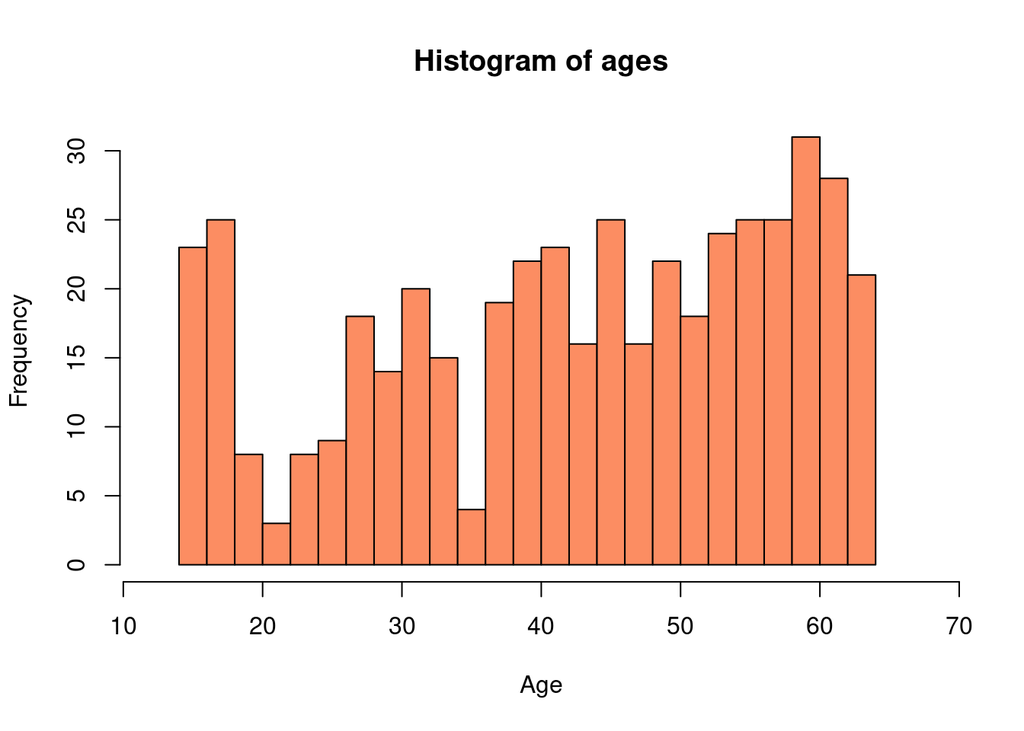

### Systolic blood pressure

As we can see the blood pressure has a similar form to a normal distribution, the mode of the data looks to be around ~130, as we know, high blood pressure is **bad.**

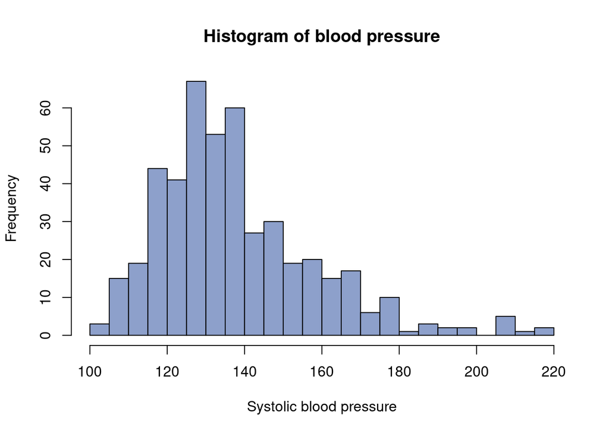

### Alcohol and Tobbaco

In this graph we can see that there is not much relation between alcohol and tobacco

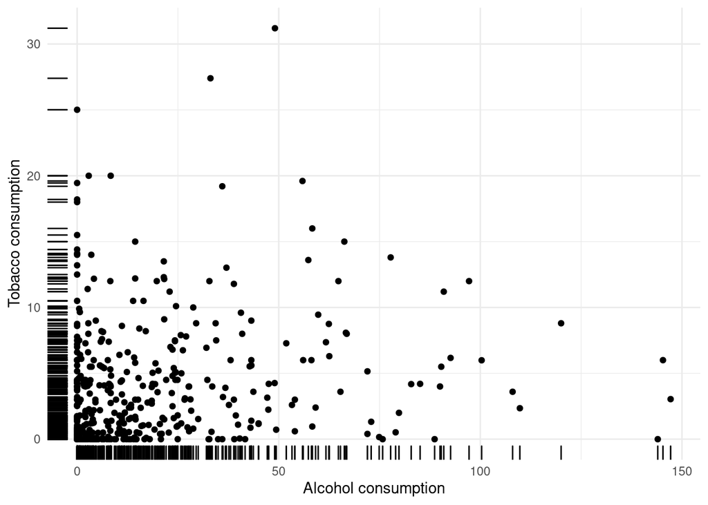

### Age, Alcohol and Tobacco consumption

I suspect that there will be a positive relation between the age and this two variables so i will plot them to confirm (Points in red mean people that has the heart disease)

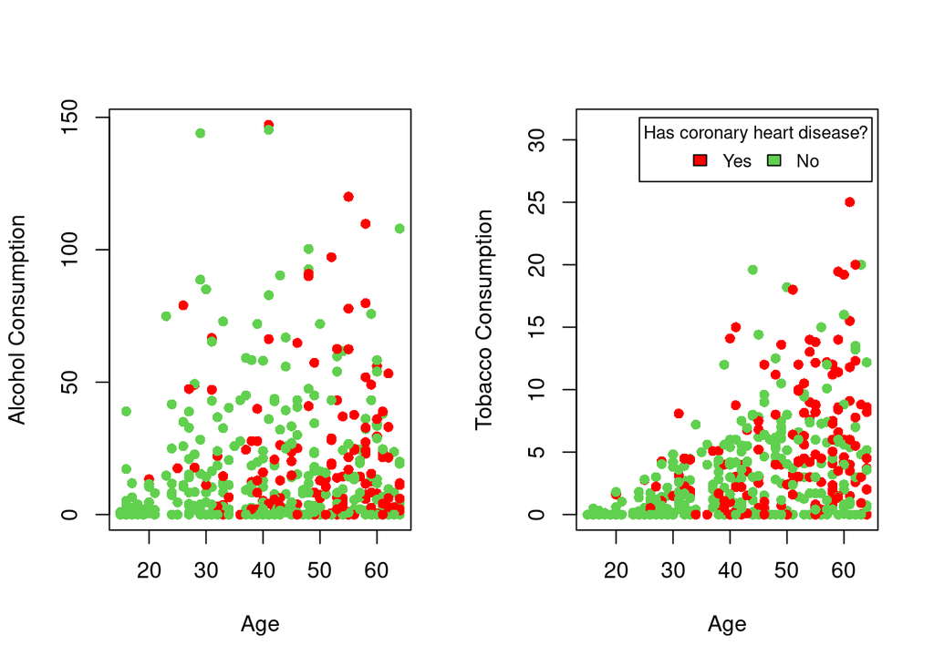

We can draw a conclusion easily, younger people do not tend to get this disease. People with ages >45 are the majority in the group of people having the heart disease.

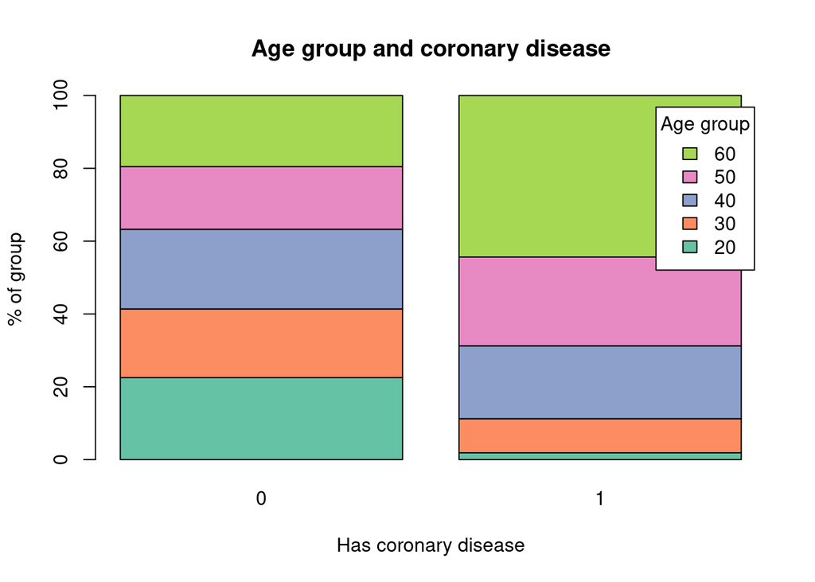

In this graph we can see that if we group the tobacco consumption by the nearest 10 and compare by having/not having the disease, the percentage of people with the disease have a higher rate of tobacco consumption than people without the disease.

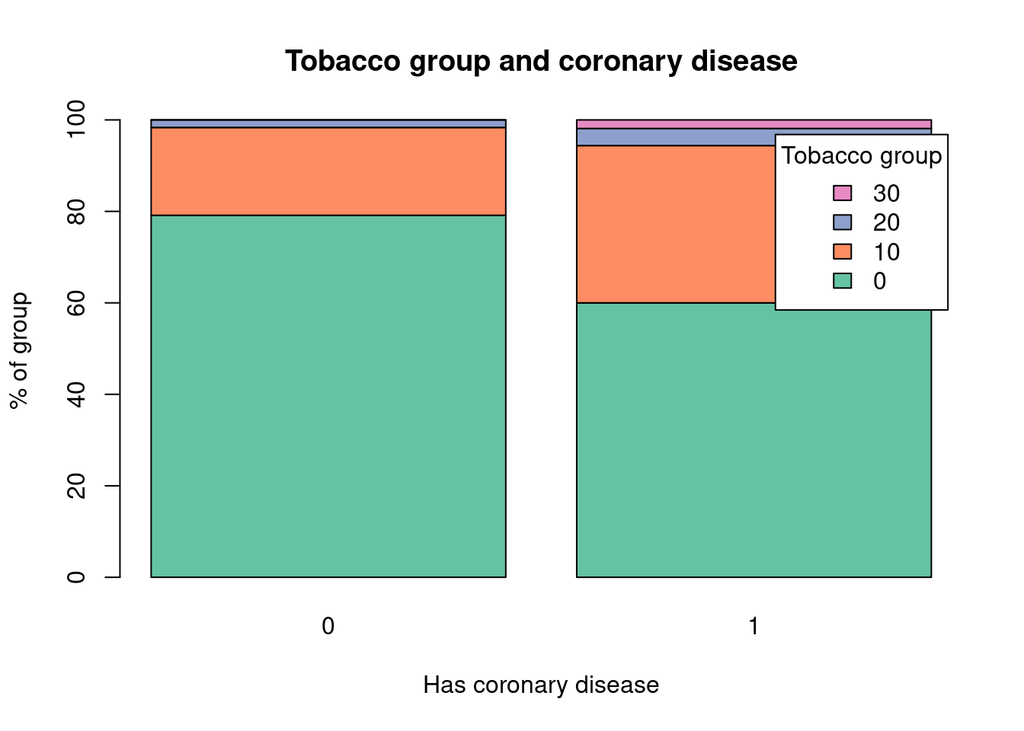

### Alcohol, Tobacco and Family history of heart disease

It is possible to think that there is some type of relation between drinking or smoking habits (often influenced by relatives).

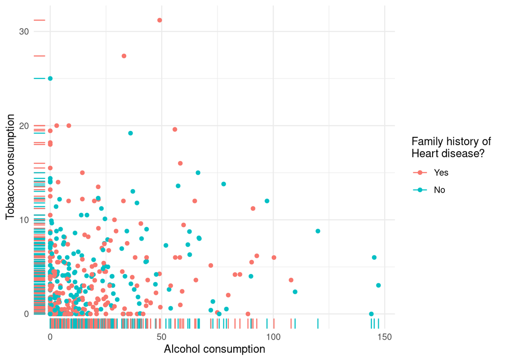

## 2.

### Sample mean vector

$\bar{\underline{x}}$

```
##               [,1]
## age      42.816017
## alcohol  17.044394
## tobacco   3.635649
## sbp     138.326840
```

```
## [1] 4 1
```